# Lecture 10 Demo: Regularization with the Hitters Data

```r
knitr::opts_chunk$set(echo = TRUE, message = FALSE, warning = FALSE)

library(ggplot2)
library(glmnet)
```

## Packages and data

This notebook uses the `Hitters` data from either `ISLR2`. The `Hitters` data record Major League Baseball players from the 1986 season. `Salary` is the response variable: annual salary in thousands of dollars.

```r
data("Hitters", package = "ISLR2")
hitters <- na.omit(Hitters)

dim(hitters)
```

```
[1] 263  20
```

```r
summary(hitters$Salary)
```

```
   Min. 1st Qu.  Median    Mean 3rd Qu.    Max.
   67.5   190.0   425.0   535.9   750.0  2460.0
```

### A quick look at the original predictors

There are 19 predictors in the original dataset, and 263 samples.

- Variables such as `AtBat`, `Hits`, `HmRun`, `Runs`, `RBI`, and `Walks` describe recent batting performance.
- Variables beginning with `C` are career totals.
- `PutOuts`, `Assists`, and `Errors` describe fielding.
- `League`, `Division`, and `NewLeague` are categorical indicators.

```r
hitters
```

|  | AtBat | Hits | HmRun | Runs | RBI | Walks | Years | CAtBat | CHits | CHmRun | CRuns | CRBI | CWalks | League | Division | PutOuts | Assists | Errors | Salary | NewLeague |
| --- | --- | --- | --- | --- | --- | --- | --- | --- | --- | --- | --- | --- | --- | --- | --- | --- | --- | --- | --- | --- |
| -Alan Ashby | 315 | 81 | 7 | 24 | 38 | 39 | 14 | 3449 | 835 | 69 | 321 | 414 | 375 | N | W | 632 | 43 | 10 | 475.000 | N |
| -Alvin Davis | 479 | 130 | 18 | 66 | 72 | 76 | 3 | 1624 | 457 | 63 | 224 | 266 | 263 | A | W | 880 | 82 | 14 | 480.000 | A |
| -Andre Dawson | 496 | 141 | 20 | 65 | 78 | 37 | 11 | 5628 | 1575 | 225 | 828 | 838 | 354 | N | E | 200 | 11 | 3 | 500.000 | N |
| -Andres Galarraga | 321 | 87 | 10 | 39 | 42 | 30 | 2 | 396 | 101 | 12 | 48 | 46 | 33 | N | E | 805 | 40 | 4 | 91.500 | N |
| -Alfredo Griffin | 594 | 169 | 4 | 74 | 51 | 35 | 11 | 4408 | 1133 | 19 | 501 | 336 | 194 | A | W | 282 | 421 | 25 | 750.000 | A |
| -Al Newman | 185 | 37 | 1 | 23 | 8 | 21 | 2 | 214 | 42 | 1 | 30 | 9 | 24 | N | E | 76 | 127 | 7 | 70.000 | A |
| -Argenis Salazar | 298 | 73 | 0 | 24 | 24 | 7 | 3 | 509 | 108 | 0 | 41 | 37 | 12 | A | W | 121 | 283 | 9 | 100.000 | A |
| -Andres Thomas | 323 | 81 | 6 | 26 | 32 | 8 | 2 | 341 | 86 | 6 | 32 | 34 | 8 | N | W | 143 | 290 | 19 | 75.000 | N |
| -Andre Thornton | 401 | 92 | 17 | 49 | 66 | 65 | 13 | 5206 | 1332 | 253 | 784 | 890 | 866 | A | E | 0 | 0 | 0 | 1100.000 | A |
| -Alan Trammell | 574 | 159 | 21 | 107 | 75 | 59 | 10 | 4631 | 1300 | 90 | 702 | 504 | 488 | A | E | 238 | 445 | 22 | 517.143 | A |

[output cut: 253 more lines]

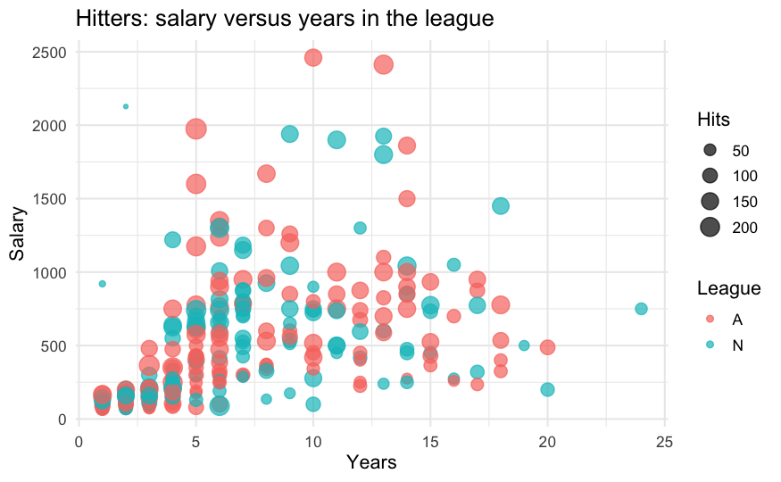

```r
ggplot(hitters, aes(x = Years, y = Salary, color = League, size = Hits)) +
  geom_point(alpha = 0.7) +
  labs(
    title = "Hitters: salary versus years in the league",
    x = "Years",
    y = "Salary"
  ) +
  theme_minimal(base_size = 13)
```

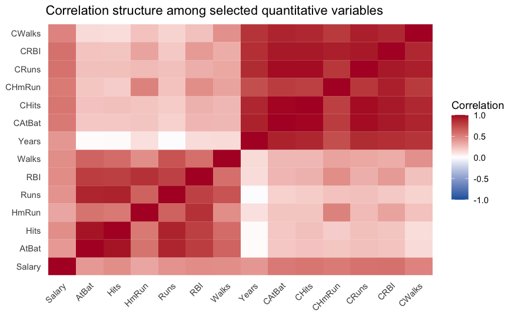

```r
num_vars <- c("Salary", "AtBat", "Hits", "HmRun", "Runs", "RBI", "Walks",
              "Years", "CAtBat", "CHits", "CHmRun", "CRuns", "CRBI", "CWalks")

corr_mat <- cor(hitters[, num_vars])

corr_df <- as.data.frame(as.table(corr_mat))
names(corr_df) <- c("Var1", "Var2", "Correlation")

ggplot(corr_df, aes(x = Var1, y = Var2, fill = Correlation)) +
  geom_tile() +
  scale_fill_gradient2(low = "#2166ac", mid = "white", high = "#b2182b",
                       midpoint = 0, limits = c(-1, 1)) +
  labs(
    title = "Correlation structure among selected quantitative variables",
    x = NULL,
    y = NULL
  ) +
  theme_minimal(base_size = 11) +
  theme(
    axis.text.x = element_text(angle = 45, hjust = 1),
    panel.grid = element_blank()
  )
```

There is substantial correlation among the career totals, and several batting variables are also strongly related. This is a good setting for regularization.

### Create a richer design matrix

To make the prediction problem more genuinely high-dimensional, we add two-way interactions among the quantitative predictors while keeping the categorical variables as main effects only.

```r
reg_formula <- Salary ~ League + Division + NewLeague +
  (AtBat + Hits + HmRun + Runs + RBI + Walks + Years +
   CAtBat + CHits + CHmRun + CRuns + CRBI + CWalks +
   PutOuts + Assists + Errors)^2

X <- model.matrix(reg_formula, data = hitters)[, -1]
y <- hitters$Salary

dim(X)
```

```
[1] 263 139
```

```r
colnames(X)[1:12]
```

```
 [1] "LeagueN"    "DivisionW"  "NewLeagueN" "AtBat"      "Hits"       "HmRun"      "Runs"       "RBI"        "Walks"      "Years"      "CAtBat"     "CHits"
```

```r
qr(X)$rank
```

```
[1] 139
```

This creates a design matrix with 139 predictors in total.

## Train/test split

```r
set.seed(32950)
n <- nrow(X)
train_id <- sample(seq_len(n), size = floor(0.8 * n))
test_id <- setdiff(seq_len(n), train_id)

X_train <- X[train_id, , drop = FALSE]
X_test <- X[test_id, , drop = FALSE]
y_train <- y[train_id]
y_test <- y[test_id]

length(train_id)
```

```
[1] 210
```

```r
length(test_id)
```

```
[1] 53
```

### OLS on the same design

```r
train_dat <- hitters[train_id, ]
test_dat <- hitters[test_id, ]

ols_fit <- lm(reg_formula, data = train_dat)
ols_pred <- predict(ols_fit, newdata = test_dat)
ols_mse <- mean((y_test - ols_pred)^2)

ols_mse
```

```
[1] 179377.1
```

Even without exact degeneracy, this expanded design makes OLS much less stable. This is exactly the kind of setting where regularization becomes useful.

## Ridge, lasso, and elastic net

We will use the `glmnet` function to run Lasso, Ridge and Elastic Net. The `glmnet` functions will estimate an intercept automatically and will not penalize it.

We first use `cv.glmnet` to choose `lambda`. The function will then fit the model with the best `lambda` on the entire training dataset. By default, `cv.glmnet` uses the number of folds `K = 10`. We will also standardize all the predictors.

```r
set.seed(32950)
cv_ridge <- cv.glmnet(X_train, y_train, alpha = 0, standardize = TRUE)

set.seed(32950)
cv_lasso <- cv.glmnet(X_train, y_train, alpha = 1, standardize = TRUE)

set.seed(32950)
cv_enet <- cv.glmnet(X_train, y_train, alpha = 0.5, standardize = TRUE)
```

### Cross-validation curves

```r
par(mfrow = c(1, 3))
plot(cv_ridge, main = "Ridge CV")
plot(cv_lasso, main = "Lasso CV")
```

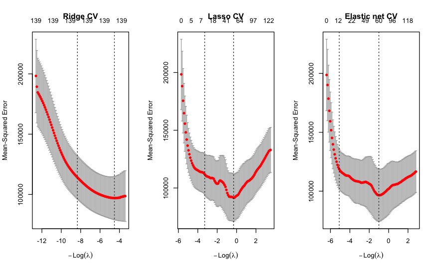

```r
plot(cv_enet, main = "Elastic net CV")
par(mfrow = c(1, 1))
```

### Test data prediction error

Use the tuning parameters selected by CV on the whole training data, and then test the models on the test data.

```r
ridge_pred <- predict(cv_ridge, newx = X_test, s = "lambda.min")
lasso_pred <- predict(cv_lasso, newx = X_test, s = "lambda.min")
enet_pred <- predict(cv_enet, newx = X_test, s = "lambda.min")

ridge_mse <- mean((y_test - ridge_pred)^2)
lasso_mse <- mean((y_test - lasso_pred)^2)
enet_mse <- mean((y_test - enet_pred)^2)

results <- data.frame(
  Method = c("OLS", "Ridge", "Lasso", "Elastic net"),
  Test_MSE = c(ols_mse, ridge_mse, lasso_mse, enet_mse)
)

results[order(results$Test_MSE), ]
```

|  | Method | Test_MSE |
| --- | --- | --- |
| 3 | Lasso | 60647.00 |
| 4 | Elastic net | 61182.69 |
| 2 | Ridge | 69532.05 |
| 1 | OLS | 179377.08 |

Lasso, Elastic net and Ridge all predict the test data much better than OLS, with Lasso performing the best here.

## Coefficient paths

We can also visualize how the coefficients change with `lambda` on the training data.

```r
ridge_fit <- glmnet(X_train, y_train, alpha = 0, standardize = TRUE)
lasso_fit <- glmnet(X_train, y_train, alpha = 1, standardize = TRUE)
enet_fit <- glmnet(X_train, y_train, alpha = 0.5, standardize = TRUE)
```

```r
par(mfrow = c(1, 3))
plot(ridge_fit, xvar = "lambda", label = FALSE, main = "Ridge path")
plot(lasso_fit, xvar = "lambda", label = FALSE, main = "Lasso path")
```

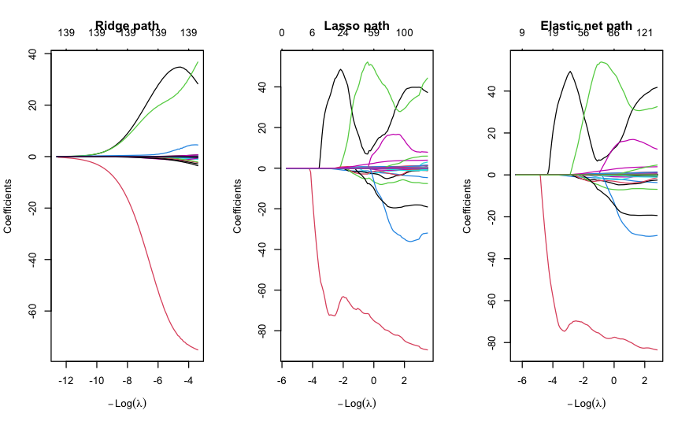

```r
plot(enet_fit, xvar = "lambda", label = FALSE, main = "Elastic net path")
par(mfrow = c(1, 1))
```

The Lasso and Elastic net paths actually very similar. The Elastic net path is just smoother because of the $\ell_2$ penalty added.

## How sparse is the lasso fit?

```r
lasso_coef <- coef(cv_lasso, s = "lambda.min")
enet_coef <- coef(cv_enet, s = "lambda.min")

sum(lasso_coef[-1, 1] != 0)
```

```
[1] 53
```

```r
sum(enet_coef[-1, 1] != 0)
```

```
[1] 60
```

```r
lasso_nonzero <- lasso_coef[lasso_coef[, 1] != 0, , drop = FALSE]
lasso_nonzero
```

```
54 x 1 sparse Matrix of class "dgCMatrix"
                   lambda.min
(Intercept)      5.348107e+02
LeagueN          8.602123e+00
DivisionW       -7.185711e+01
NewLeagueN       5.058167e+01
AtBat           -1.456531e+00
Hits            -2.925791e+00
HmRun            1.870931e+00
Runs            -2.139482e+00
RBI             -2.298497e+00
Walks           -4.853590e+00
CHits            3.329951e-01
CRuns            7.069482e-01
CRBI             1.895966e-01
CWalks           5.206373e-01
PutOuts          3.072278e-01
Assists          2.070375e+00
Errors          -7.617525e+00
AtBat:Hits       3.320834e-03
AtBat:Walks      3.748820e-04
AtBat:Years      5.824630e-02
AtBat:CWalks     1.332638e-03
AtBat:Assists   -1.280061e-03
Hits:HmRun       1.344806e-01
Hits:Walks       7.223271e-02
Hits:Assists    -1.465332e-03
Hits:Errors      2.194851e-05
HmRun:RBI       -3.128173e-02
HmRun:CAtBat    -5.534970e-03
HmRun:CHmRun     8.095777e-02
HmRun:CRBI       2.288763e-02
HmRun:CWalks    -4.280627e-02
HmRun:PutOuts   -3.850681e-03
HmRun:Assists   -1.492172e-02
HmRun:Errors    -3.231415e-01
Runs:CRBI        3.560147e-04
Runs:Errors      6.072413e-02
RBI:CRBI         3.964278e-03
Walks:Years     -2.285219e-03
Walks:PutOuts   -2.003278e-03
Walks:Assists   -6.429953e-03
Walks:Errors     3.312738e-02
Years:CAtBat    -1.496781e-02
Years:Errors    -2.030175e-01
CAtBat:CHmRun   -1.215814e-04
CAtBat:Assists   4.543147e-05
CHits:PutOuts    4.403663e-04
CHits:Errors     6.742580e-05
CHmRun:CRBI      2.900925e-07
CHmRun:PutOuts  -1.009738e-03
CHmRun:Errors    9.663381e-03
CRBI:Errors      2.646156e-02
CWalks:Assists  -2.295138e-03
PutOuts:Assists -1.357541e-03
Assists:Errors   7.169966e-03
```

## Takeaway

- OLS becomes unstable on the full interaction-expanded design.
- Ridge stabilizes the fit by shrinking all coefficients.
- Lasso performs both shrinkage and variable selection.
- Elastic net gives a compromise between sparsity and stability.